# `Prosper Loan Dataset Exploration`

## by Swati Chanchal

## Preliminary Wrangling

> This is a datset of Proser Loans , Prosper makes personal loans easy. Whether you're consolidating debt or remodeling your home, we have a solution for you. This data set contains 113,937 loans with 81 variables on each loan, including loan amount, borrower rate (or interest rate), current loan status, borrower income, and many others. (Last updated 03/11/2014)

### What is the structure of your dataset?

> This data set contains 113,937 loans with 81 variables . Rows = 113,937 and Columns = 81

### What is/are the main feature(s) of interest in your dataset?

> There are so many variables in this dataset.Trying to figure out what features can be used to predict .

### What features in the dataset do you think will help support your investigation into your feature(s) of interest?

> According to me the features which going to help me are Borrower Monthly Payment, Borrower Occupation, Borrower State, Borrower Employment Status , Borrower Rate, Borrower APR, Prosper Score, Loan Amount .

## Univariate Exploration

### Checking for Missing Values , as there is lots of variables present checking this visually is a great idea .

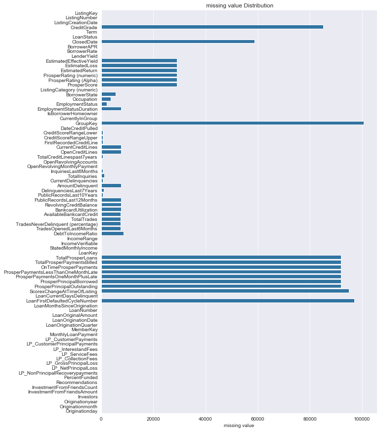

```python
plt.figure(figsize = [10,15])
na_counts = df.isna().sum()
sb.barplot(na_counts, na_counts.index.values, color = base_color);
lables_name('missing value')
```

### 1. Loan Status :

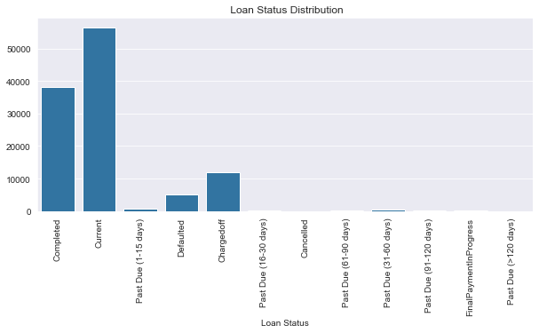

```python
plt.figure(figsize = [10,4])
sb.countplot(data = df , x = 'LoanStatus' , color =base_color);
plt.xticks(rotation = 90);
lables_name('Loan Status')
```

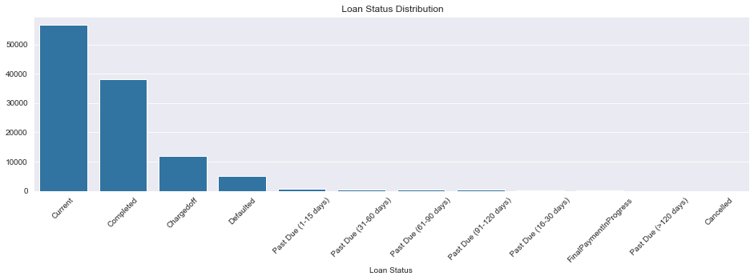

```python
plt.figure(figsize = [16,4])
sb.countplot(data = df , x = 'LoanStatus' , color =base_color , order=order);
plt.xticks(rotation = 45);
lables_name('Loan Status')
```

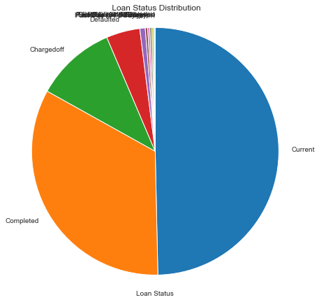

```python
plt.figure(figsize = [7,14])
counts = df['LoanStatus'].value_counts()
plt.pie(counts, labels = counts.index, startangle = 90,
        counterclock = False);
plt.axis('square')
lables_name('Loan Status')
```

### 2. Prosper Rating :

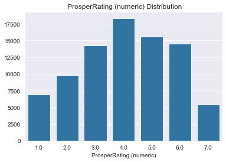

```python
sb.countplot(data = df , x = 'ProsperRating (numeric)' , color =base_color);
lables_name('ProsperRating (numeric)')
```

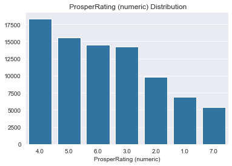

```python
sb.countplot(data = df , x = 'ProsperRating (numeric)' , color =base_color , order = order);
lables_name('ProsperRating (numeric)')
```

### Observation :

- majority of borrower has Prosper Rating 4 ,5 , 6 and 3 .

### 3. Employment Status :

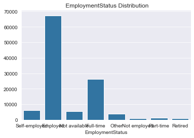

```python
sb.countplot(data = df , x = 'EmploymentStatus' , color =base_color);
lables_name('EmploymentStatus')
```

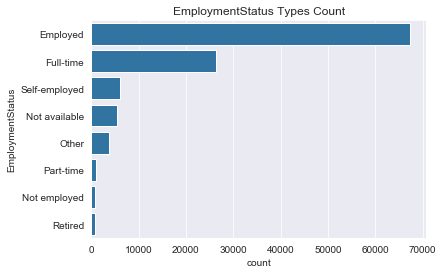

```python
order = df['EmploymentStatus'].value_counts().index
sb.countplot(data = df , y = 'EmploymentStatus' , color =base_color , order = order);
plt.title('EmploymentStatus Types Count');
```

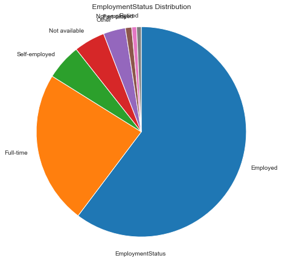

```python
plt.figure(figsize = [7,14])
counts = df['EmploymentStatus'].value_counts()
plt.pie(counts, labels = counts.index, startangle = 90,
        counterclock = False);
plt.axis('square')
lables_name('EmploymentStatus')
```

### Observation :

- around 60% borrowers are employed .
- and 20 % are Full-Time worker.

### 4. Occupation Type :

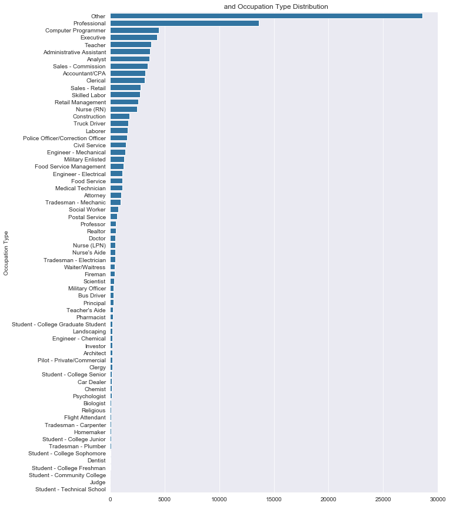

```python
plt.figure(figsize = [10,15])
order = df['Occupation'].value_counts().index
sb.countplot(data = df , y = 'Occupation' , color =base_color , order = order);
lables_name('' , 'Occupation Type')
```

### Observation :

- the higest category of borrower who take loans are Others , and then professionals .

### 5. Borrower Rate

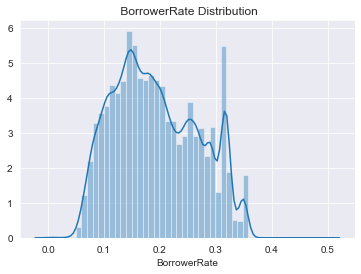

```python
sb.distplot(df['BorrowerRate']);
lables_name('BorrowerRate')
```

### Observation :

- most of the people has borrower rate between 0.1 to 0.2
- mean is 0.18 .

### 6. Borrower APR :

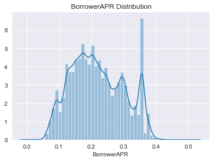

```python
sb.distplot(df['BorrowerAPR']);
lables_name('BorrowerAPR')
```

### 7. Is Borrower Home Owner :

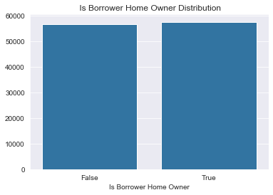

```python
sb.countplot(data = df , x = 'IsBorrowerHomeowner' , color =base_color);
lables_name('Is Borrower Home Owner')
```

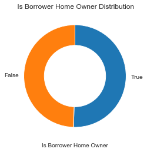

```python
counts = df['IsBorrowerHomeowner'].value_counts()
plt.pie(counts, labels = counts.index, startangle = 90,
        counterclock = False, wedgeprops = {'width' : 0.4});
lables_name('Is Borrower Home Owner')
```

### Observation :

- 50% od borrowers have their own home
- and 50% don't have their own home .

### 8. Loan Original Amount

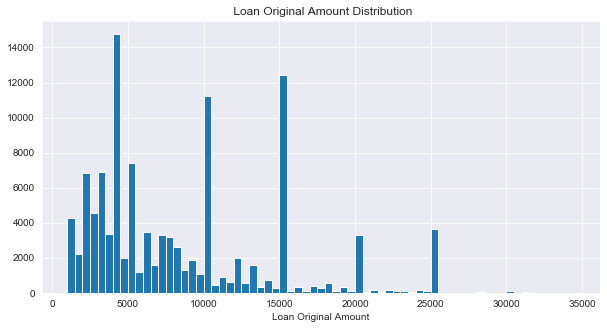

```python
plt.figure(figsize = [10,5])
bins = np.arange(df['LoanOriginalAmount'].min(), df['LoanOriginalAmount'].max(), 500)
plt.hist(data = df, x = 'LoanOriginalAmount', bins = bins);
lables_name('Loan Original Amount')
```

### Observation :

- amount that borrowed many times are 4500 , 10500 and 15000 .

### 9. Borrower State

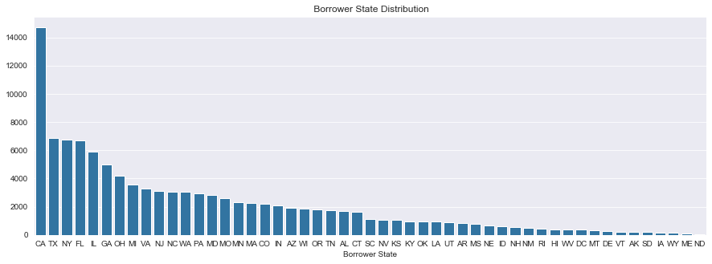

```python
plt.figure(figsize=(15,5))
order = df['BorrowerState'].value_counts().index
sb.countplot(data = df , x = 'BorrowerState' , color =base_color , order = order);
lables_name('Borrower State')
```

### Observation :

- the highest borrowers quantity is from CA (California )
- and in TX , NY , FL (Texas , New York , Florida ) has almost same no. of borrowers .

### 10 . Credit Score Range :

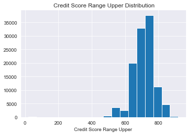

```python
bins = np.arange(df['CreditScoreRangeUpper'].min(),df['CreditScoreRangeUpper'].max() + 50, 50)
plt.hist(data = df , x = 'CreditScoreRangeUpper' , bins = bins);
lables_name('Credit Score Range Upper')
```

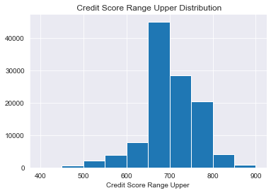

```python
bins = np.arange(400,df['CreditScoreRangeUpper'].max() + 50, 50)
plt.hist(data = df , x = 'CreditScoreRangeUpper' , bins = bins);
lables_name('Credit Score Range Upper')
```

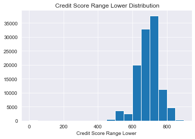

```python
bins = np.arange(df['CreditScoreRangeLower'].min(),df['CreditScoreRangeLower'].max() + 50, 50)
plt.hist(data = df , x = 'CreditScoreRangeLower' , bins = bins);
lables_name('Credit Score Range Lower')
```

### Discuss the distribution(s) of your variable(s) of interest. Were there any unusual points? Did you need to perform any transformations?

> All the graph I plotted , mostly are normally distributed .In the case of Borrower state there is a great difference between the 1st highest state(california ) and 2nd highest state(Texas) .I don't think transformation is needed as I'm just investigating the datset .

### Of the features you investigated, were there any unusual distributions? Did you perform any operations on the data to tidy, adjust, or change the form of the data? If so, why did you do this?

> In case of original loan amount (loan original amount) I found that it is Multimodel . A multimodal distribution is a probability distribution with more than one peak, or “mode.”

## Bivariate Exploration

### 1. Loan Origination Year vs Loan Origination Amount

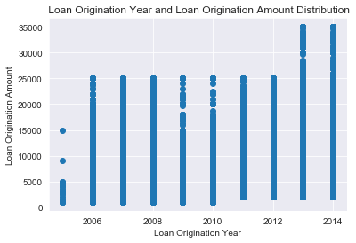

```python
plt.scatter(data = df , x= 'Originationyear' , y = 'LoanOriginalAmount');
lables_name('Loan Origination Year' , 'Loan Origination Amount')
```

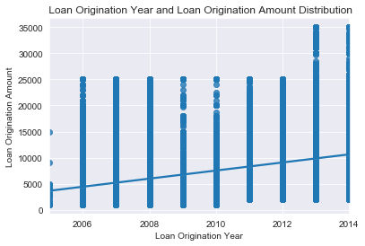

```python
sb.regplot(data = df , x= 'Originationyear' , y = 'LoanOriginalAmount');
lables_name('Loan Origination Year' , 'Loan Origination Amount')
```

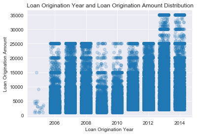

```python
sb.regplot(data = df , x= 'Originationyear' , y = 'LoanOriginalAmount'
           , fit_reg = False ,x_jitter = 0.3 , scatter_kws = {'alpha' : 1/5});
lables_name('Loan Origination Year' , 'Loan Origination Amount')
```

### Observation :

- at earliers years borrowed amount is used to be less comparetively.
- as shown by the regplot also , the line is tending to increase with the year

### 2. Borrower Rate vs Loan Origination Year

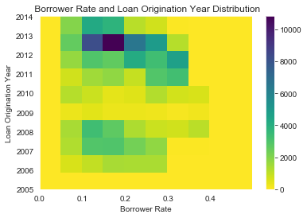

```python
plt.hist2d(data = df , y= 'Originationyear' , x = 'BorrowerRate' , cmap = 'viridis_r'  );
plt.colorbar()
lables_name('Borrower Rate' , 'Loan Origination Year')
```

### Observation :

- borrower rate tends to increasing with year , and then deceresing .

### Quantitative vs Qualitative

### 3. Credit Grade vs Monthly Loan Payment

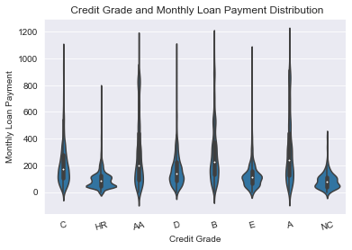

```python
sb.violinplot(data = df, x = 'CreditGrade', y = 'MonthlyLoanPayment',color = base_color);
plt.xticks(rotation = 15);
lables_name('Credit Grade' , 'Monthly Loan Payment')
```

### 4. Loan Origination Year vs Borrower Rate

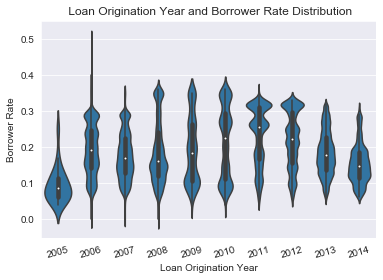

```python
sb.violinplot(data = df, x = 'Originationyear', y = 'BorrowerRate',color = base_color);
plt.xticks(rotation = 15);
lables_name('Loan Origination Year' , 'Borrower Rate')
```

### 5. Employment status vs Borrower APR

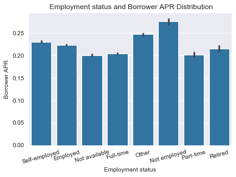

```python
sb.barplot(data = df, x = 'EmploymentStatus', y = 'BorrowerAPR',color = base_color );
plt.xticks(rotation = 15)
lables_name('Employment status' , 'Borrower APR')
```

### Observation :

- the highest borrower APR is of Non Employed borrowers
- it is followed by Others , Self-Employed and Employed.

### 6. Income Range vs Borrower APR

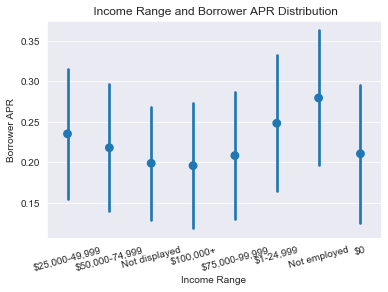

```python
sb.pointplot(data = df, x = 'IncomeRange', y = 'BorrowerAPR', linestyles = '' , ci = 'sd');
plt.xticks(rotation = 15);
lables_name('Income Range' , 'Borrower APR')
```

### Observation :

- the highest borrower APR are again for Non - Employed .
- and it is followed by borrowers with income range $1-24,999
- the lowest borrower rate is of income range $100,000

### 7. Employment Status vs Borrower Rate

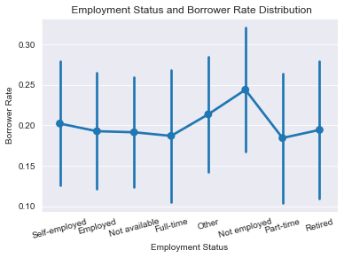

```python
sb.pointplot(data = df, x = 'EmploymentStatus', y = 'BorrowerRate',color = base_color , ci = 'sd');
plt.xticks(rotation = 15);
lables_name('Employment Status' , 'Borrower Rate')
```

### Observation :

- heighest borrower rate is of borrower with Non - Employed Status

### 8. Borrower Rate vs Loan Status

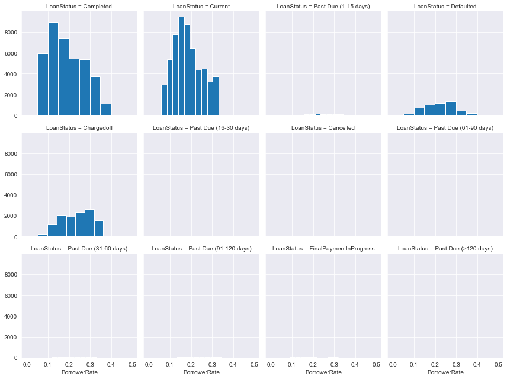

```python
bins = np.arange(0.0 , 0.42 , 0.03)
g = sb.FacetGrid(data = df , col = 'LoanStatus' , col_wrap =4)
g.map(plt.hist , 'BorrowerRate');
```

## Qualitative vs Qualitative

### 9 . Employment Status vs Prosper Score

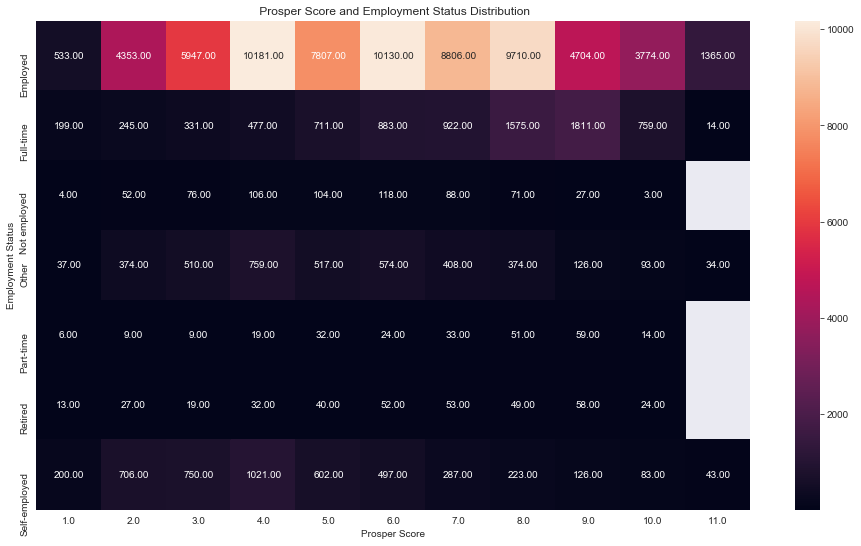

```python
plt.figure(figsize = [16,9])
sb.heatmap(ct_counts , annot =True , fmt = '.2f');
lables_name('Prosper Score' , 'Employment Status' )
```

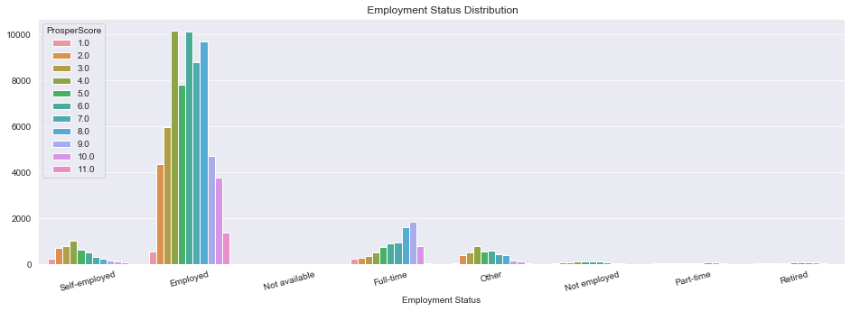

```python
plt.figure(figsize = [16,5])
ax = sb.countplot(data = df, x = 'EmploymentStatus' , hue = 'ProsperScore');
plt.xticks(rotation = 15);
lables_name('Employment Status')
# ax.legend(loc = 8, ncol = 3, framealpha = 1, title = 'ProsperScore')
```

### Observation

- Prosper rating is highest fro Employed Borrowers .
- the difference in the no. of Prosper Rated Borrowers in different Employment status is very large .

### 10 . LoanStatus vs Is Borrower Home owner

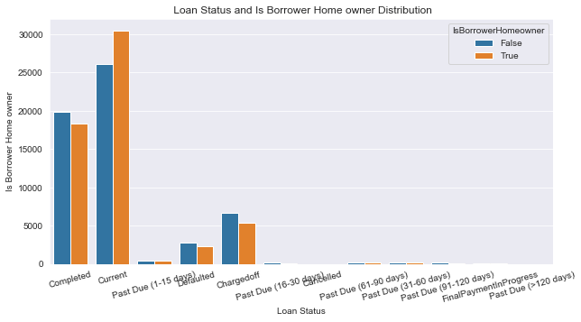

```python
plt.figure(figsize = [10,5])
ax = sb.countplot(data = df, x = 'LoanStatus' , hue = 'IsBorrowerHomeowner');
plt.xticks(rotation = 15);
lables_name('Loan Status' , 'Is Borrower Home owner')
```

### Observation :

- Currently Active Loan borrowers are the highest with Owed Home .

### Did you observe any interesting relationships between the other features (not the main feature(s) of interest)?

> I found Prosper rating , Is borrower owned home and Ocupation intresting .